## Progetto di Fondamenti di Scienza dei Dati e Laboratorio A.A.2025/2026

Sebastiano Assaloni

[figure not shown]

# Un'Analisi sulle Contee in West Virginia e Ohio

## Background

- I PFAS (sostanze per- e polifluoroalchiliche) sono composti chimici sintetici utilizzati in ambito industriale per la loro elevata stabilità chimica.
- Il PFOA è stato storicamente impiegato nella produzione del Teflon e di altri fluoropolimeri.
- Lo stabilimento DuPont(azienda inventrice del Teflon) Washington Works, situato a Parkersburg (West Virginia), ha operato lungo il fiume Ohio a partire dagli anni ’40, rilasciando PFOA nell’ambiente per diversi decenni.
- Questo studio si concentra sulle contee situate a valle dello stabilimento, storicamente esposte alla contaminazione lungo il corso del fiume.

## Obbiettivi e curiosità da cui è nato lo studio

- Verificare se le contee storicamente esposte alla contaminazione da PFAS lungo il fiume Ohio presentino tassi di incidenza del tumore renale più elevati rispetto ai valori di riferimento nazionali e statali.
- Di seguito tre link: il primo sulla correlazione PFAS-Cancro, il secondo sullo scandalo DuPont, il terzo rimanda al video di Barbascura
- https://www.airc.it/cancro/informazioni-tumori/corretta-informazione/i-pfas-possono-causare-il-cancro
- https://www.ewg.org/news-insights/news/why-are-dupont-and-chemours-still-discharging-most-notorious-forever-chemical
- https://www.youtube.com/watch?v=FpqzpRLxnkM&t=3s

## Dataset utilizzati

- Dati di incidenza del tumore renale a livello di contea.
- Tasso di incidenza aggiustato per età (casi per 100.000 abitanti).
- Stati analizzati: West Virginia, Ohio e Stati Uniti (baseline nazionale).
- Periodo di riferimento coerente con i dati SEER/NPCR disponibili(2017-2021).

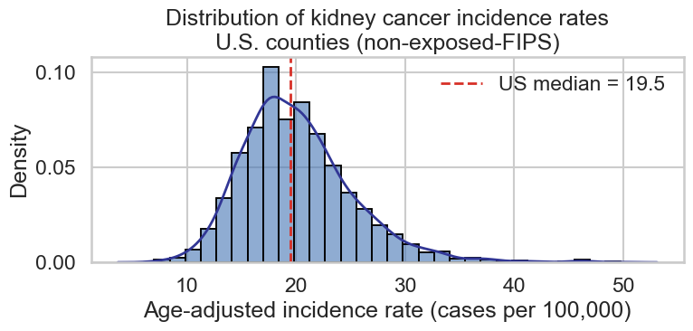

## Baseline Nazionale

- La mediana del tasso di incidenza aggiustato per età del tumore renale nelle contee statunitensi è pari a 19.5 casi per 100.000 abitanti.
- Questo valore viene utilizzato come riferimento per il confronto con le contee esposte e non esposte.

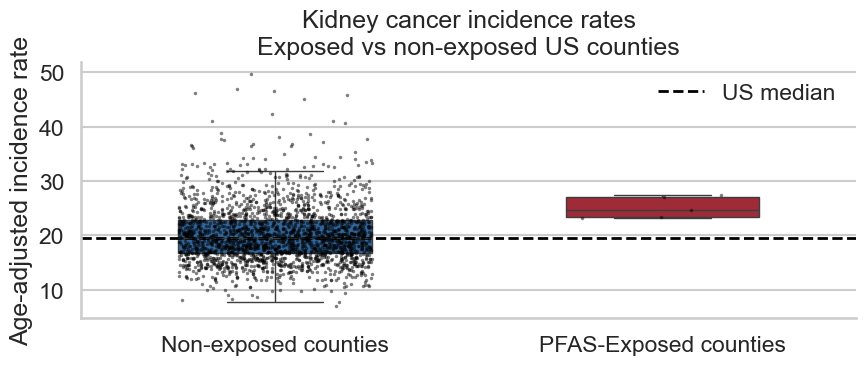

## Posizionamento nel contesto nazionale

- Nel contesto della distribuzione complessiva delle contee statunitensi, quelle esposte si collocano nella parte superiore dell’intervallo dei tassi osservati.
- I valori osservati non risultano distribuiti casualmente rispetto alla baseline nazionale.

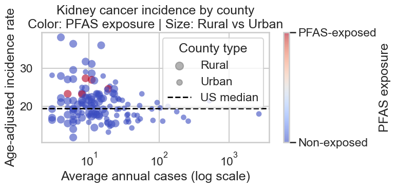

## Confronto contee esposte vs non esposte Ohio e West Virgina

- Le contee di riferimento presentano valori d'incidenza sistematicamente superiori alla mediana nazionale.
- Altre contee mostrano una distribuzione dei tassi più vicina al valore di riferimento nazionale.

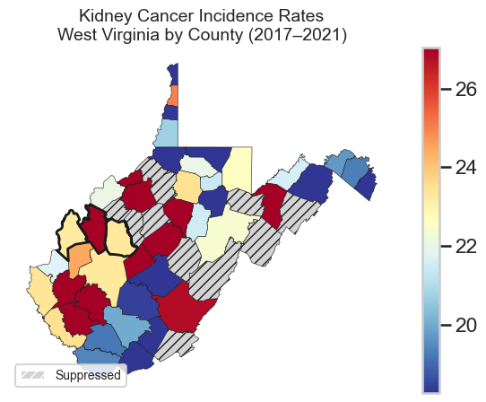

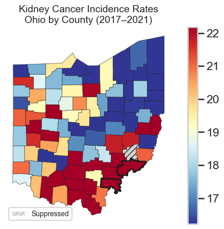

## Contesto geografico

Visualizzazione grafica fiume Ohio e dintorni

[figure not shown]

## Limiti dello studio

## Considerazioni metodologiche

- L’analisi si basa su dati aggregati a livello di contea.
- Non è possibile stabilire relazioni causali a partire dai dati osservazionali utilizzati.
- Le stime nelle contee rurali possono essere soggette a maggiore variabilità.

## Conclusione

- L’analisi mostra che le contee storicamente esposte lungo il fiume Ohio presentano valori di incidenza del tumore renale sistematicamente superiori al riferimento nazionale.
- I risultati evidenziano differenze territoriali persistenti che meritano ulteriori approfondimenti epidemiologici.